# 2. Bias-variance decomposition

Michał Maj

2021-03-02

# 1 Statystyczna teoria decyzji

## 1.1 Ryzyko estymacji

Przypuśćmy, że obserwujemy pewną zmienną $Y \in \mathbb{R}$ oraz zestaw predyktorów $X = (X_1, X_2, X_3, …, X_p) \in \mathbb{R^p}$ z rozkładem łącznym $\mathbb{P}(X, Y)$ . Naszym celem jest **predykcja** $Y$ za pomocą $X$. Przez predykcję mamy na myśli to, aby $f(X)$ było dostatecznie blisko $Y$, czyli:

$$Y ≈ f(X)$$

Pytanie brzmi co oznacza dostaecznie blisko, jak znaleźć rozwiązanie **optymalne**? Optymalność może znaczyć wiele różnych rzeczy i zależy od naszego punktu widzenia. W pierwszej kolejności musimy ustalić jak będziemy oceniać czy nasze rozwiązanie jest optymalne. Wybierzmy tak zwaną **funkcję straty**:

$$L(Y, f(X))$$

którą będziemy chcieli **zminimalizować**. Jedną z częściej spotykanych jest **kwadratowa funkcja straty**:

$$L(Y, f(X)) = (Y - f(X))^2$$

Ponieważ nie jesteśmy w stanie zminimalizować powyższej funkcji (mamy do czynienia ze zmiennymi losowymi), zminimalizujemy jej wartość oczekiwaną, czyli tak zwaną **funkcję ryzyka**:

$$R(f) = \mathbb{E}_{X, Y}[(Y - f(X))^2]$$

Pierwszym krokiem będzie przepisanie funkcji ryzyka warunkujac po $X$ (korzystamy tutaj z własności wartości oczekiwanej $\mathbb{E}(Y) = \mathbb{E}(\mathbb{E}(Y|X))$):

$$\mathbb{E}_{X, Y}\left[(Y-f(X))^{2}\right]=\mathbb{E}_{X} \mathbb{E}_{Y \mid X}\left[(Y-f(X))^{2} \mid X=x\right]$$

Łatwo teraz zauważyć, że minimalizacja całego wyrażenia sprowadza się do minimalizacji wewnetrznej wartości oczekiwanej, a to tak na prawdę oznacza minimalizację ryzyka punktowo dla każdego $x$. Skorzystaliśmy tutaj z ponizszego faktu:

$$\begin{equation}
\mathbb{E}[(Y-f(X))^{2} \mid X] =
\mathbb{E}(([Y-\mathbb{E}(Y \mid X)] + [\mathbb{E}(Y \mid X)-f(X)])^{2} \mid X) = \\
\mathbb{E}((Y-\mathbb{E}(Y \mid X))^{2} \mid X)+\mathbb{E}((\mathbb{E}(Y \mid X)-f(X))^{2} \mid X)+\\
2 \mathbb{E}((Y-\mathbb{E}(Y \mid X))(\mathbb{E}(Y \mid X)-f(X)) \mid X) =\\
\mathbb{E}((Y-\mathbb{E}(Y \mid X))^{2} \mid X)+\mathbb{E}((\mathbb{E}(Y \mid X)-f(X))^{2} \mid X)+\\
2(\mathbb{E}(Y \mid X)-f(X)) \mathbb{E}(Y-\mathbb{E}(Y \mid X)) \mid X)=\\
\mathbb{E}((Y-\mathbb{E}(Y \mid X))^{2} \mid X)
+\mathbb{E}((\mathbb{E}(Y \mid X)-f(X))^{2} \mid X)
\geq \mathbb{E}((Y-\mathbb{E}(Y \mid X))^{2} \mid X)
\end{equation}$$

Okazuje się, ze w tym przypadku kandydatem na $f$ jest warunkowa wartość oczekiwana:

$$f(x) = \mathbb{E}(Y| X = x)$$
i nazywać będzidmy ją $funkcją regresji$. Zauważmy jeszcze, że wybór kwadratowej funkcji straty jest arbitralny. Jeśli zamiast niej wybralibśmy np. **absolutną funkcję straty**:

$$L(Y, f(X)) = |Y - f(X)|$$
to kandydatem na $f$ byłaby **warunkowa mediana**:

$$f(x) = median(Y| X = x)$$

## 1.2 Redukowalny i nieredukowalny błąd estymacji

Do tej pory rozmawialiśmy o zmiennych losowych, jednakże w prawdziwym życiu dysponować będziemy wyłącznie realizacjami $X$ oraz $Y$, tak zwanym **zbiorem treningowym** $\mathcal{D}=\left\{\left(\mathbf{x}_{i}, y_{i}\right)\right\}_{i=1}^{N}$, a naszym celem będzie znalezienie funkcji $\hat{f}$, która jest optymalnym estymatorem funkcji regresji $f$.

Przypuśćmy, że w pewien sposób otrzyaliśmy $\hat{f}$, pytanie brzmi jak dobrze estymuje ono $f$? Aby odpowiedzieć na to pytanie zdefiniujmy **oczekiwany błąd predykcji** (expected prediction error):

$$\text{EPE}\left(Y, \hat{f}(X)\right) = \mathbb{E}_{X, Y, \mathcal{D}} \left[ \left( Y - \hat{f}(X) \right)^2 \right]$$

Zauważmy, że warunkujemy nie tylko ze wzdlędu na $X, Y$, ale także ze względu na $\mathcal{D}$ ($\hat{f}$ jest losowa i zalezy od zbioru trenngowego $\mathcal{D}$). Tak jak poprzednio zwarunkujemy względem $X = x$, aby otrzymać oczekiwany błąd predykcji $Y$ używając $X$ gdy $X = x$:

$$\text{EPE}\left(Y, \hat{f}(x)\right) =
\mathbb{E}_{Y \mid X, \mathcal{D}} \left[ \left(Y - \hat{f}(X) \right)^2 \mid X = x \right] =\\
\mathbb{E}_{Y \mid X, \mathcal{D}} \left[ \left((Y - f(X)) + (f(X) - \hat{f}(X)) \right)^2 \mid X = x \right] =\\
\underbrace{\mathbb{E}_{\mathcal{D}} \left[ \left(f(x) - \hat{f}(x) \right)^2 \right]}_\textrm{redukowalny bład} +
\underbrace{\mathbb{V}_{Y \mid X} \left[ Y \mid X = x \right]}_\textrm{nieredukowalny bład}$$

Zauważmy, że nasz błąd został rozbity na 2 części:

- **błąd redukowalny** który w zasadzie jest oczekiwaną (średnią) kwadratową stratą w przypadku estymacji $f(x)$ używając $\hat{f}(x)$ w danym punkcie $x$. W przyszłości będziey go oznaczać mianem **błędu średniokwadratowego**:

$$MSE(f(x), \hat{f}(x)) = \mathbb{E}_{\mathcal{D}} [(f(x) - \hat{f}(x))^2]$$

- **błąd nieredukowalny** będący wariancją $Y$ gdy $X = x$. Jest to szum, którego nie jesteśmy w satanie i nie powinniśmy się nauczyć. W przyszłości będziemy go nazywać mianem **czynnika Bayesa** (Bayes factor).

## 1.3 Dekompozycja bias-variance

Po dekompozycji oczekiwanego błedu predykcji, możemy dalej zastanawiać się nad błędem redukowalnym i jego składowymi:

$$\text{MSE}\left(f(x), \hat{f}(x)\right) =
\mathbb{E}_{\mathcal{D}} \left[ \left(f(x) - \hat{f}(x) \right)^2 \right] = \\
\mathbb{E}_{\mathcal{D}} \left[ \left((f(x) - \mathbb{E}[\hat{f}(x)]) + (\mathbb{E}[\hat{f}(x)] - \hat{f}(x)) \right)^2 \right] = \\
\underbrace{\left(f(x) - \mathbb{E} \left[ \hat{f}(x) \right] \right)^2}_{\text{bias}^2 \left(\hat{f}(x) \right)} +
\underbrace{\mathbb{E} \left[ \left( \hat{f}(x) - \mathbb{E} \left[ \hat{f}(x) \right] \right)^2 \right]}_{\text{var} \left(\hat{f}(x) \right)}$$
Jak widzimy błąd sredniokwadratwy rozbity został na 2 kolejne składniki:

- **obciązenie** (bias)
- **wariancję** (variance)

$$\text{MSE}\left(f(x), \hat{f}(x)\right) = \text{bias}^2 \left(\hat{f}(x) \right) + \text{var} \left(\hat{f}(x) \right)$$
W idealnym świecie chcielibyśmy znaleźć **nieobciazone** $\hat{f}$, które jednocześnie posiada małą wariancje, jednak często jest to niemożliwe. W praktyce zmniejszając wariancję naszego modelu, bardzo często zwiększawy obiążenie i odwrotnie. Jest to tak zwany **bias-variance tradeoff**.

Bardziej skomplikowane modele (np. sieci neuronowe) z natury są mniej obciażone jednakże posiadają większą wariancje, odwrotnie jest przy prostych modelach jak na przykład model liniowy.

W kontekście regresji i klasyfikacji obciązenie modelu wzrasta gdy:

- struktura modelu jest zbyt mało elastyczna dla opisywanego zjawiska (np. model liniowy nie jest w stanie opisać zjawiska nieliniowego)
- model jest zbyt mocno wwygładzany / regularyzowany

Wariancja modelu wzrasta gdy:

- struktura modelu jest zbyt elastyczna, na przykład gdy użyjemy sieci neuronowych lub modelu wielomianowego do opisania zjawiska liniowego
- w modelu uwzględniamy zbyt dużo zmiennych

Na zakonczenie mozemy jeszcze zapisać pełną dekompozycję oczekiwanego błędu predykcji:

$$\text{EPE}\left(Y, \hat{f}(x)\right) =
\underbrace{\text{bias}^2\left(\hat{f}(x)\right) + \text{var}\left(\hat{f}(x)\right)}_\textrm{reducible error} + \sigma^2.$$

gdzie $\mathbb{V}[Y \mid X = x] = \sigma ^ 2$

Poniższy wykres przedstawia dekompozycję bias-variance w przypadku róznego udziału obciazenia i wariancji w calości błedu

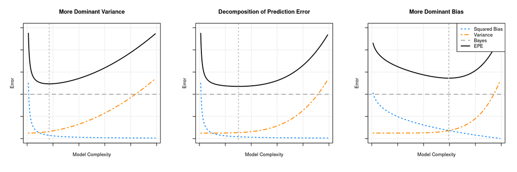

## 1.4 Overfitting i underfitting

Do tej pory mówiliśmy tylko i wyłącznie o **optymalizacji**, bedącej tylko jednym z dwóch zadań modelowania statystycznego (machine learningu). Optymalizacja mówi nam o dopasowaniu modelu do pewnej konkretnej realizacji zmiennych $X$ oraz $Y$, którą nazywamy zbiorem treningowym, jednakze w rzeczywistości zależy nam na dobrej **generalizacji** naszego rozwiązania, czyli dobrego dopasowania modelu (niskiego błędu) na niezaobserwowanych realizacjach owych zmiennych - **zbiorach testowych**.

Kompromis między generalizacją, a optymalizacja jest innym spojrzeniem na bias-variance tradeoff. W istocie jeśli uzywamy zbyt elastycznego modelu co może prowadzić do wysokiej wariancji jesteśmy w stanie skutecznie zmniejszyc błąd zbioru treningowego, jednakże błąd zbioru testowego moze zacząć wzrastać wraz ze złożonością modelu. Jest to tak zwany **overfitting**. W przypadku overfittingu model zaczyna “uczyć” wzorców z szumu (nieredukowalnego błędu) zbioru treningowego.

Zjawiskiem odwrotnym jest **underfitting**, w którym to nasz model jest za mało elastyczny co skutkuje obserwacją wysokiego błędu na zbiorze testowym jak i treningowym. Ponizszy wykres przedstawia oba zjawiska:

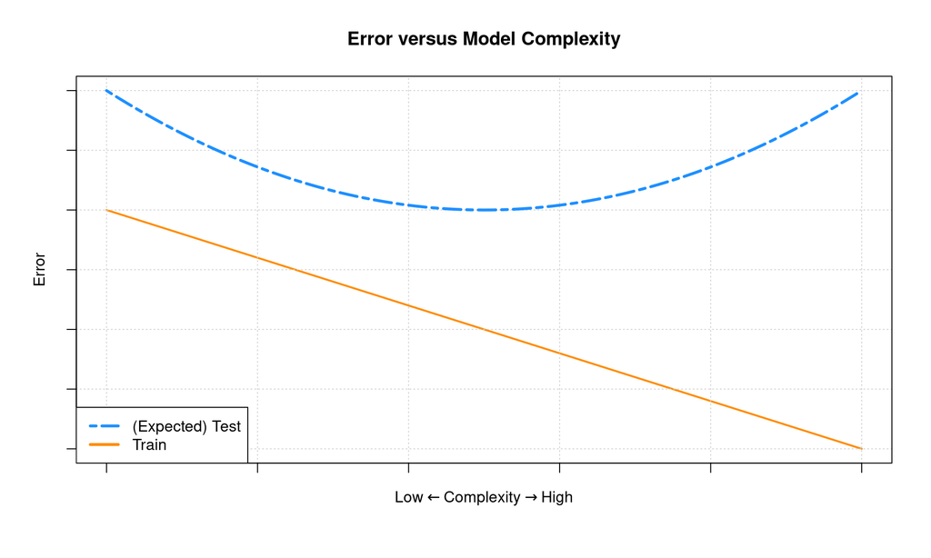

W praktyce zbiór treningowy dzielimy na zbiór treningowy i walidacyjny/testowy (lub stosujemy metody takie jak cross-validacja). Model trenowany (uczony) jest na części treningowej, a estypacja błędu predykcji robiona jest na części walidacyjnej/testowej w celu lepszej reprezentacji **błędu generalizacji**.